# Chapter 5

## Lee Sang Yoon (2016270905)

# 5.3 Exercises

```r
library(dslabs)
library(tidyverse)
```

```r
library(NHANES)
library(readxl)
library(dplyr)
library(stringr)
library(splitstackshape)
library(ggpubr)
library(ggplot2)
library(data.table)
library(purrr)
library(readr)
library(readxl)
```

## 1. Use the read_csv function to read each of the files that the following code saves in the files object:

```r
library(readxl)
path <- system.file("extdata", package = "dslabs")
path
```

```
## [1] "C:/Users/user/AppData/Local/R/win-library/4.2/dslabs/extdata"
```

```r
files <- list.files(path)
files
```

```
## [1] "2010_bigfive_regents.xls"
## [2] "carbon_emissions.csv"
## [3] "fertility-two-countries-example.csv"
## [4] "HRlist2.txt"
## [5] "life-expectancy-and-fertility-two-countries-example.csv"
## [6] "murders.csv"
## [7] "olive.csv"
## [8] "RD-Mortality-Report_2015-18-180531.pdf"
## [9] "ssa-death-probability.csv"
```

```r
getwd()
```

```
## [1] "C:/Users/user/Documents/R_project/bsms222_905_lee"
```

```r
setwd("C:/Users/user/AppData/Local/R/win-library/4.2/dslabs/extdata")

fullpath<- file.path(path, files)
fullpath
```

```
## [1] "C:/Users/user/AppData/Local/R/win-library/4.2/dslabs/extdata/2010_bigfive_regents.xls"
## [2] "C:/Users/user/AppData/Local/R/win-library/4.2/dslabs/extdata/carbon_emissions.csv"
## [3] "C:/Users/user/AppData/Local/R/win-library/4.2/dslabs/extdata/fertility-two-countries-example.csv"
## [4] "C:/Users/user/AppData/Local/R/win-library/4.2/dslabs/extdata/HRlist2.txt"
## [5] "C:/Users/user/AppData/Local/R/win-library/4.2/dslabs/extdata/life-expectancy-and-fertility-two-countries-example.csv"
## [6] "C:/Users/user/AppData/Local/R/win-library/4.2/dslabs/extdata/murders.csv"
## [7] "C:/Users/user/AppData/Local/R/win-library/4.2/dslabs/extdata/olive.csv"
## [8] "C:/Users/user/AppData/Local/R/win-library/4.2/dslabs/extdata/RD-Mortality-Report_2015-18-180531.pdf"
## [9] "C:/Users/user/AppData/Local/R/win-library/4.2/dslabs/extdata/ssa-death-probability.csv"
```

```r
read_csv(files[2])
```

| Year | Total carbon emissions from fossil fuel consumption and cement production (million metric tons of C) |
| --- | --- |
| 1751 | 3 |
| 1752 | 3 |
| 1753 | 3 |
| 1754 | 3 |
| 1755 | 3 |
| 1756 | 3 |
| 1757 | 3 |
| 1758 | 3 |
| 1759 | 3 |
| 1760 | 3 |

[output cut: 254 more lines]

```r
read_csv(files[3])
```

| country | 1960 | 1961 | 1962 | 1963 | 1964 | 1965 | 1966 | 1967 | 1968 | 1969 | 1970 | 1971 | 1972 | 1973 | 1974 | 1975 | 1976 | 1977 | 1978 | 1979 | 1980 | 1981 | 1982 | 1983 | 1984 | 1985 | 1986 | 1987 | 1988 | … |
| --- | --- | --- | --- | --- | --- | --- | --- | --- | --- | --- | --- | --- | --- | --- | --- | --- | --- | --- | --- | --- | --- | --- | --- | --- | --- | --- | --- | --- | --- | --- |
| Germany | 2.41 | 2.44 | 2.47 | 2.49 | 2.49 | 2.48 | 2.44 | 2.37 | 2.28 | 2.17 | 2.04 | 1.92 | 1.80 | 1.70 | 1.62 | 1.56 | 1.53 | 1.50 | 1.49 | 1.48 | 1.47 | 1.47 | 1.46 | 1.46 | 1.46 | 1.45 | 1.44 | 1.43 | 1.41 | … |
| South Korea | 6.16 | 5.99 | 5.79 | 5.57 | 5.36 | 5.16 | 4.99 | 4.85 | 4.73 | 4.62 | 4.53 | 4.41 | 4.27 | 4.09 | 3.87 | 3.62 | 3.36 | 3.11 | 2.88 | 2.69 | 2.52 | 2.38 | 2.24 | 2.11 | 1.98 | 1.86 | 1.75 | 1.67 | 1.63 | … |

```r
read_csv(files[5])
```

| country | 1960_fertility | 1960_life_expectancy | 1961_fertility | 1961_life_expectancy | 1962_fertility | 1962_life_expectancy | 1963_fertility | 1963_life_expectancy | 1964_fertility | 1964_life_expectancy | 1965_fertility | 1965_life_expectancy | 1966_fertility | 1966_life_expectancy | 1967_fertility | 1967_life_expectancy | 1968_fertility | 1968_life_expectancy | 1969_fertility | 1969_life_expectancy | 1970_fertility | 1970_life_expectancy | 1971_fertility | 1971_life_expectancy | 1972_fertility | 1972_life_expectancy | 1973_fertility | 1973_life_expectancy | 1974_fertility | … |
| --- | --- | --- | --- | --- | --- | --- | --- | --- | --- | --- | --- | --- | --- | --- | --- | --- | --- | --- | --- | --- | --- | --- | --- | --- | --- | --- | --- | --- | --- | --- |
| Germany | 2.41 | 69.26 | 2.44 | 69.85 | 2.47 | 70.01 | 2.49 | 70.10 | 2.49 | 70.66 | 2.48 | 70.65 | 2.44 | 70.77 | 2.37 | 70.99 | 2.28 | 70.64 | 2.17 | 70.48 | 2.04 | 70.72 | 1.92 | 70.94 | 1.80 | 71.16 | 1.70 | 71.41 | 1.62 | … |
| South Korea | 6.16 | 53.02 | 5.99 | 53.75 | 5.79 | 54.51 | 5.57 | 55.27 | 5.36 | 56.04 | 5.16 | 56.84 | 4.99 | 57.67 | 4.85 | 58.54 | 4.73 | 59.44 | 4.62 | 60.35 | 4.53 | 61.22 | 4.41 | 62.02 | 4.27 | 62.73 | 4.09 | 63.34 | 3.87 | … |

```r
read_csv(files[6])
```

| state | abb | region | population | total |
| --- | --- | --- | --- | --- |
| Alabama | AL | South | 4779736 | 135 |
| Alaska | AK | West | 710231 | 19 |
| Arizona | AZ | West | 6392017 | 232 |
| Arkansas | AR | South | 2915918 | 93 |
| California | CA | West | 37253956 | 1257 |
| Colorado | CO | West | 5029196 | 65 |
| Connecticut | CT | Northeast | 3574097 | 97 |
| Delaware | DE | South | 897934 | 38 |
| District of Columbia | DC | South | 601723 | 99 |
| Florida | FL | South | 19687653 | 669 |

[output cut: 41 more lines]

```r
read_csv(files[7])
```

| ...1 | Region | Area | palmitic | palmitoleic | stearic | oleic | linoleic | linolenic | arachidic | eicosenoic |
| --- | --- | --- | --- | --- | --- | --- | --- | --- | --- | --- |
| 1 | North-Apulia | 1 | 1 | 1075 | 75 | 226 | 7823 | 672 | 36 | 60,29 |
| 2 | North-Apulia | 1 | 1 | 1088 | 73 | 224 | 7709 | 781 | 31 | 61,29 |
| 3 | North-Apulia | 1 | 1 | 911 | 54 | 246 | 8113 | 549 | 31 | 63,29 |
| 4 | North-Apulia | 1 | 1 | 966 | 57 | 240 | 7952 | 619 | 50 | 78,35 |
| 5 | North-Apulia | 1 | 1 | 1051 | 67 | 259 | 7771 | 672 | 50 | 80,46 |
| 6 | North-Apulia | 1 | 1 | 911 | 49 | 268 | 7924 | 678 | 51 | 70,44 |
| 7 | North-Apulia | 1 | 1 | 922 | 66 | 264 | 7990 | 618 | 49 | 56,29 |
| 8 | North-Apulia | 1 | 1 | 1100 | 61 | 235 | 7728 | 734 | 39 | 64,35 |
| 9 | North-Apulia | 1 | 1 | 1082 | 60 | 239 | 7745 | 709 | 46 | 83,33 |
| 10 | North-Apulia | 1 | 1 | 1037 | 55 | 213 | 7944 | 633 | 26 | 52,30 |

[output cut: 562 more lines]

```r
read_csv(files[9])
```

| Age | Sex | DeathProb | NumberOfLives | LifeExp |
| --- | --- | --- | --- | --- |
| 0 | Male | 0.006383 | 100000 | 76.15 |
| 1 | Male | 0.000453 | 99362 | 75.63 |
| 2 | Male | 0.000282 | 99317 | 74.67 |
| 3 | Male | 0.000230 | 99289 | 73.69 |
| 4 | Male | 0.000169 | 99266 | 72.71 |
| 5 | Male | 0.000155 | 99249 | 71.72 |
| 6 | Male | 0.000145 | 99234 | 70.73 |
| 7 | Male | 0.000135 | 99219 | 69.74 |
| 8 | Male | 0.000120 | 99206 | 68.75 |
| 9 | Male | 0.000105 | 99194 | 67.76 |

[output cut: 230 more lines]

## Read the help file for read_csv to figure out how to read in the file without reading this header. If you skip the header, you should not get this warning. Save the result to an object called dat.

```r
setwd("C:/Users/user/AppData/Local/R/win-library/4.2/dslabs/extdata")
dat<- read.csv(files[7], header=FALSE)
dat
```

| V1 | V2 | V3 | V4 | V5 | V6 | V7 | V8 | V9 | V10 | V11 | V12 |
| --- | --- | --- | --- | --- | --- | --- | --- | --- | --- | --- | --- |
| NA | Region | Area | palmitic | palmitoleic | stearic | oleic | linoleic | linolenic | arachidic | eicosenoic | NA |
| 1 | North-Apulia | 1 | 1 | 1075 | 75 | 226 | 7823 | 672 | 36 | 60 | 29 |
| 2 | North-Apulia | 1 | 1 | 1088 | 73 | 224 | 7709 | 781 | 31 | 61 | 29 |
| 3 | North-Apulia | 1 | 1 | 911 | 54 | 246 | 8113 | 549 | 31 | 63 | 29 |
| 4 | North-Apulia | 1 | 1 | 966 | 57 | 240 | 7952 | 619 | 50 | 78 | 35 |
| 5 | North-Apulia | 1 | 1 | 1051 | 67 | 259 | 7771 | 672 | 50 | 80 | 46 |
| 6 | North-Apulia | 1 | 1 | 911 | 49 | 268 | 7924 | 678 | 51 | 70 | 44 |
| 7 | North-Apulia | 1 | 1 | 922 | 66 | 264 | 7990 | 618 | 49 | 56 | 29 |
| 8 | North-Apulia | 1 | 1 | 1100 | 61 | 235 | 7728 | 734 | 39 | 64 | 35 |
| 9 | North-Apulia | 1 | 1 | 1082 | 60 | 239 | 7745 | 709 | 46 | 83 | 33 |

[output cut: 563 more lines]

## 3. A problem with the previous approach is that we don’t know what the columns represent. Type:

```r
names(dat)
```

```
##  [1] "V1"  "V2"  "V3"  "V4"  "V5"  "V6"  "V7"  "V8"  "V9"  "V10" "V11" "V12"
```

## to see that the names are not informative.

## Use the readLines function to read in just the first line (we later learn how to extract values from the output).

```r
setwd("C:/Users/user/AppData/Local/R/win-library/4.2/dslabs/extdata")
read_lines(files[7], n_max=1)
```

```
## [1] ",Region,Area,palmitic,palmitoleic,stearic,oleic,linoleic,linolenic,arachidic,eicosenoic"
```

# 5.9 Exercises

## 1. Pick a measurement you can take on a regular basis. For example, your daily weight or how long it takes you to run 5 miles. Keep a spreadsheet that includes the date, the hour, the measurement, and any other informative variable you think is worth keeping. Do this for 2 weeks. Then make a plot.

```r
getwd()
```

```
## [1] "C:/Users/user/Documents/R_project/bsms222_905_lee"
```

```r
setwd("C:/Users/user/Documents/R_project/bsms222_905_lee")
dat2<- read_csv("Shoulder press weight (kg).csv")
```

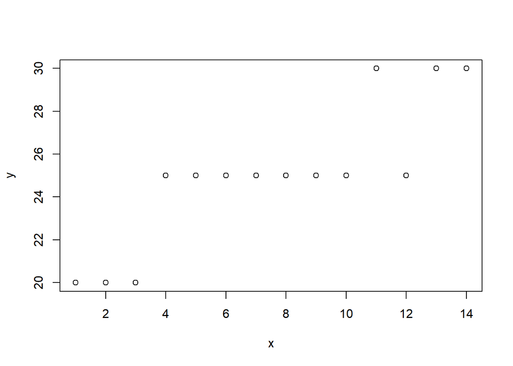

```r
x<- dat2$day
y<- dat2$weight

plot(x,y)
```